# CAViaR Analysis

Steven Moen

6/20/19

# Modified Code

The code below sets up all the key libraries.

```
The working directory was changed to /Users/stevenmoen/Documents/GitHub/CAViaR inside a notebook chunk. The working directory will be reset when the chunk is finished running. Use the knitr root.dir option in the setup chunk to change the working directory for notebook chunks.
```

Let’s convert all of the key bits to functions. Below we pull the data

```r
#' This is a functino which pulls data for use
#'
#' @param symbol - symbol to pull
#' @param compl_case - defaults to true...only includes complete cases in the data
#' @param adj_close - use adjusted closing prices. Default is yes.
#' @param log_return - use log return? Default is yes.
#'
#' @return - a data frame which can be fed into later functions
#' @export
#'
#' @examples - data_pull("SPY")
data_pull = function(symbol, compl_case = 1, adj_close = 1, log_return = 1, start_date = "1900-01-01", end_date = Sys.Date()){
  # Pull in data from quantmod
  response_pull = getSymbols(symbol, auto.assign = FALSE, from = start_date, to = end_date)
  # Get adjusted closing price
  if (adj_close == TRUE){
    df = Ad(response_pull)
  } else {
    df = Cl(response_pull)
  }
  # Return complete cases only
  if (compl_case == TRUE){
    df = df[complete.cases(df), ]
  } else{
    df = df
  }
  # Calculate log return of data
  if (log_return == TRUE){
    lr = log(df[,1]/shift(df[,1], 1, type = "lag"))
    # Combine data
    df_out = cbind(df, lr)
    # Rename the data
    colnames(df_out) <- c(symbol, paste0(symbol, "_log_return"))
  } else{
    df_out = df
  }
  # Return data
  return(df_out)
}
# ibm = data_pull("IBM", start_date = "1986-04-06", end_date = "1999-04-08")
```

```r
#' Pull the data and run the caviar function on it
#'
#' @param input_data - data to use in the function
#' @param range_data - range of the data to use
#'
#' @return - a list of values from the caviar function
#' @export
#'
#' @examples - caviar_pull(spy)
caviar_pull = function(input_data, range_data = (2:dim(input_data)[1])){
  # Run the caviar data
  caviar <- caviarOptim(input_data[range_data,2])
  return(caviar)
}
```

```r
#' Function for producing rolling predictions
#' Model 1 = Symmetric Absolute Value, 2 = Asymmetric slope, 3 = Indirect GARCH, 4 = Adaptive
#'
#' @param input_data - input data from the previous function
#' @param range_data - range of the data to consider
#' @param nfcst - number of forecasts to make
#' @param model - model to use (integers 1 through 4). Defaults to 1.
#' @param level - level of significance to use.
#' @param G - argument for the k parameter in the 4th model (adaptive). Default is 5
#'
#' @return - an xts object which contains rolling CAViaR predictions
#' @export
#'
#' @examples - rolling_predictions(spy, nfcst = 22)
rolling_predictions = function(input_data, range_data = (2:dim(input_data)[1]), nfcst = 250, model =1, level = 0.01, G = 5){
  # Run the varpredict function
  varpredict <- rollapplyr(input_data[range_data,2], length(range_data) - nfcst, caviarOptim, model, level, predict = 1, k = G) %>% lag
  # Eliminate NAs
  # pred_no_na = na.omit(varpredict)
  # Return the data
  # return(pred_no_na)
  return(varpredict)
}
# spy = data_pull("SPY")
```

Below is the comparison of the methods.

```r
out10 = rolling_predictions(spy, nfcst = 1, model = 4, G = 10)
out5 = rolling_predictions(spy, nfcst = 1, model = 4, G = 5)
out_def = rolling_predictions(spy, nfcst = 1, model = 4, G = 5)

tail(out10)
tail(out5)
tail(out_def)

# Plot the data
# plot(spy$SPY_log_return)
# lines(-out, col = "red")
```

[output not shown]

We now need to write a function which analyzes accuracy of the data.

# Verification

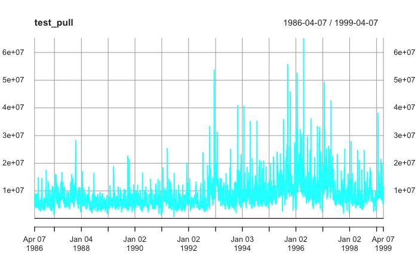

It looks like we’re missing some data points, but visually, it doesn’t look like there is a missing clump of data

Let’s use the IBM data to analyze if we can reproduce the data seen in the paper.

```r
# ibm_verif = loss_calc("IBM", start_dt = "1986-04-06", end_dt = "1999-04-08", 200)
# ibm_verif_m = loss_calc("IBM", start_dt = "1986-04-06", end_dt = "1999-04-08", 800)
# ibm_verif_l = loss_calc("IBM", start_dt = "1986-04-06", end_dt = "1999-04-08", 1600)
```

It looks like the paper uses data from April 7th through April 7th, 1999, using the last 500 for out-of-sample testing. An update on 9/17 is that we will update the G parameter to be 10.

```r
# Uses the fourth model, 1% VaR, G = 10
ibm_verif_pap_m4_1pc_g10 = loss_calc("IBM", start_dt = "1986-04-06", end_dt = "1999-04-08", model=4, 500, level = 0.01, G = 10)
```

Now, let’s export the IBM data since it took so long to run.

```r
# Initialize a list for IBM runs
ibm_list = list()
ibm_list[[1]] = ibm_verif_pap_m4_1pc_g10
ibm_list[[2]] = ibm_verif_pap_m4_5pc_g10
# Export the IBM data
for (i in 1:2){
# for (i in 1:8){
  # Join the data
  join = merge(ibm_list[[i]][[4]],ibm_list[[i]][[3]],all=TRUE)
  # Add an id column
  if (i == 2){
    join$var_level = 0.05
    join$model = 4
  }
  else {
    join$var_level = 0.01
    join$model = 4
  }
  # Add a run
  join$id = i*4
  colnames(join) <- c("Fcst_VaR", "Act_Return", "var_level", "model", "id")
  # Convert to a zoo
  join2 = as.zoo(join)
  # Define another dummy
  j = 4*i
  # Export the data
  write.zoo(join2, file = paste0("/Users/stevenmoen/Documents/GitHub/CAViaR_MS_thesis/Data_Export/091719/ibm_result_pr_g10", j))
}
```

```r
# Uses the first model, 1% VaR
ibm_verif_pap_m1_1pc = loss_calc("IBM", start_dt = "1986-04-06", end_dt = "1999-04-08", model=1, 500, level = 0.01)

# Uses the second model, 1% VaR
ibm_verif_pap_m2_1pc = loss_calc("IBM", start_dt = "1986-04-06", end_dt = "1999-04-08", model=2, 500, level = 0.01)

# Uses the third model, 1% VaR
ibm_verif_pap_m3_1pc = loss_calc("IBM", start_dt = "1986-04-06", end_dt = "1999-04-08", model=3, 500, level = 0.01)

# Uses the fourth model, 1% VaR
ibm_verif_pap_m4_1pc = loss_calc("IBM", start_dt = "1986-04-06", end_dt = "1999-04-08", model=4, 500, level = 0.01)

# Uses the first model, 5% VaR
ibm_verif_pap_m1_5pc = loss_calc("IBM", start_dt = "1986-04-06", end_dt = "1999-04-08", model=1, 500, level = 0.05)

# Uses the second model, 5% VaR
ibm_verif_pap_m2_5pc = loss_calc("IBM", start_dt = "1986-04-06", end_dt = "1999-04-08", model=2, 500, level = 0.05)

# Uses the third model, 5% VaR
ibm_verif_pap_m3_5pc = loss_calc("IBM", start_dt = "1986-04-06", end_dt = "1999-04-08", model=3, 500, level = 0.05)

# Uses the fourth model,5% VaR
ibm_verif_pap_m4_5pc = loss_calc("IBM", start_dt = "1986-04-06", end_dt = "1999-04-08", model=4, 500, level = 0.05)
```

# PG and Amazon test

OVERNIGHT TEST - PG and AMZN.

```r
# Initialize a list for a high-volatility stock, AMZN
# amzn_list = list()

# Initialize a list for a high-volatility stock, PG
# PG_list = list()
```

```r
# amzn_list[[1]] = loss_calc("AMZN", "2007-01-01","2008-12-31", 200)
# amzn_list[[2]] = loss_calc("AMZN", "2006-10-01","2008-12-31", 200)
# amzn_list[[3]] = loss_calc("AMZN", "2006-07-01","2008-12-31", 200)
# amzn_list[[4]] = loss_calc("AMZN", "2006-04-01","2008-12-31", 200)
# amzn_list[[5]] = loss_calc("AMZN", "2006-01-01","2008-12-31", 200)
# amzn_list[[6]] = loss_calc("AMZN", "2005-10-01","2008-12-31", 200)
# amzn_list[[7]] = loss_calc("AMZN", "2005-07-01","2008-12-31", 200)
# amzn_list[[8]] = loss_calc("AMZN", "2005-04-01","2008-12-31", 200)
# amzn_list[[9]] = loss_calc("AMZN", "2005-01-01","2008-12-31", 200)
# amzn_list[[10]] = loss_calc("AMZN", "2004-10-01","2008-12-31", 200)
# amzn_list[[11]] = loss_calc("AMZN", "2004-07-01","2008-12-31", 200)
# amzn_list[[12]] = loss_calc("AMZN", "2004-04-01","2008-12-31", 200)
#
#
#
# PG_list[[1]] = loss_calc("PG", "2007-01-01","2008-12-31", 200)
# PG_list[[2]] = loss_calc("PG", "2006-10-01","2008-12-31", 200)
# PG_list[[3]] = loss_calc("PG", "2006-07-01","2008-12-31", 200)
# PG_list[[4]] = loss_calc("PG", "2006-04-01","2008-12-31", 200)
# PG_list[[5]] = loss_calc("PG", "2006-01-01","2008-12-31", 200)
# PG_list[[6]] = loss_calc("PG", "2005-10-01","2008-12-31", 200)
# PG_list[[7]] = loss_calc("PG", "2005-07-01","2008-12-31", 200)
# PG_list[[8]] = loss_calc("PG", "2005-04-01","2008-12-31", 200)
# PG_list[[9]] = loss_calc("PG", "2005-01-01","2008-12-31", 200)
# PG_list[[10]] = loss_calc("PG", "2004-10-01","2008-12-31", 200)
# PG_list[[11]] = loss_calc("PG", "2004-07-01","2008-12-31", 200)
# PG_list[[12]] = loss_calc("PG", "2004-04-01","2008-12-31", 200)
#
#
# amzn_list
# PG_list
```

# Exporting the 1 percent IBM daata

```r
# Initialize a list for IBM runs
ibm_list = list()

ibm_list[[1]] = ibm_verif_pap_m1_1pc
ibm_list[[2]] = ibm_verif_pap_m2_1pc
ibm_list[[3]] = ibm_verif_pap_m3_1pc
ibm_list[[4]] = ibm_verif_pap_m4_1pc
ibm_list[[5]] = ibm_verif_pap_m1_5pc
ibm_list[[6]] = ibm_verif_pap_m2_5pc
ibm_list[[7]] = ibm_verif_pap_m3_5pc
ibm_list[[8]] = ibm_verif_pap_m4_5pc


# Export the IBM data
# for (i in 1:1){
for (i in 1:8){
  # Join the data
  join = merge(ibm_list[[i]][[4]],ibm_list[[i]][[3]],all=TRUE)
  # Add an id column
  if ((i/4) > 1){
    join$var_level = 0.05
    join$model = i - 4
  }
  else {
    join$var_level = 0.01
    join$model = i
  }
  # Add a run
  join$id = i
  colnames(join) <- c("Fcst_VaR", "Act_Return", "var_level", "model", "id")
  # Convert to a zoo
  join2 = as.zoo(join)
  # Export the data
  write.zoo(join2, file = paste0("/Users/stevenmoen/Documents/GitHub/CAViaR/CSV_IBM_090419/ibm_result_pr", i))
}

# for (i in 1:4){
#   join = merge(paste0("ibm_verif_pap_m", i,"_1pc")[[4]],paste0("ibm_verif_pap_m", i,"_1pc")[[3]],all=TRUE)
#   join$model_type = i
#   colnames(join) <- c("Fcst_VaR", "Act_Return", "model_type")
#   join2 = as.zoo(join)
#   write.zoo(join2, file = paste0("/Users/stevenmoen/Documents/GitHub/CAViaR/CSV_IBM_090419/ibm_result_", i))
# }
```

# Analyzing the IBM Data

```r
# Read in the data - 4th and 8th results are modified from the prior result
ibm_1 = read.csv("/Users/stevenmoen/Documents/GitHub/CAViaR/CSV_IBM_090419/ibm_result_pr1", header = T, sep = " ")
ibm_2 = read.csv("/Users/stevenmoen/Documents/GitHub/CAViaR/CSV_IBM_090419/ibm_result_pr2", header = T, sep = " ")
ibm_3 = read.csv("/Users/stevenmoen/Documents/GitHub/CAViaR/CSV_IBM_090419/ibm_result_pr3", header = T, sep = " ")
ibm_4 = read.csv("/Users/stevenmoen/Documents/GitHub/CAViaR_MS_thesis/Data_Export/091719/ibm_result_pr_g104", header = T, sep = " ")
ibm_5 = read.csv("/Users/stevenmoen/Documents/GitHub/CAViaR/CSV_IBM_090419/ibm_result_pr5", header = T, sep = " ")
ibm_6 = read.csv("/Users/stevenmoen/Documents/GitHub/CAViaR/CSV_IBM_090419/ibm_result_pr6", header = T, sep = " ")
ibm_7 = read.csv("/Users/stevenmoen/Documents/GitHub/CAViaR/CSV_IBM_090419/ibm_result_pr7", header = T, sep = " ")
ibm_8 = read.csv("/Users/stevenmoen/Documents/GitHub/CAViaR_MS_thesis/Data_Export/091719/ibm_result_pr_g108", header = T, sep = " ")
# Combine into a single file
ibm_big = rbind(ibm_1, ibm_2, ibm_3, ibm_4, ibm_5, ibm_6, ibm_7, ibm_8)
# See when there is a hit and add onto the dataset
breach = ifelse(ibm_big$Act_Return > ibm_big$Fcst_VaR, 0, 1)
ibm_big = cbind(ibm_big, breach)
# Summarize the data
ibm_sum <- ibm_big %>%
  select(var_level, model, breach) %>%
  group_by(var_level, model) %>%
  summarize(total_breach = sum(breach))
# Calculate hit rate
ibm_sum$hit_rate <- ibm_sum$total_breach/500
ibm_sum
```

| var_level | model | total_breach | hit_rate |
| --- | --- | --- | --- |
| 0.01 | 1 | 7 | 0.014 |
| 0.01 | 2 | 7 | 0.014 |
| 0.01 | 3 | 9 | 0.018 |
| 0.01 | 4 | 7 | 0.014 |
| 0.05 | 1 | 27 | 0.054 |
| 0.05 | 2 | 35 | 0.070 |
| 0.05 | 3 | 36 | 0.072 |
| 0.05 | 4 | 31 | 0.062 |

```r
# Add a table from the CAViaR paper
ibm_sum$paper_hit_rate <- c(0.016, 0.016, 0.016, 0.016, 0.06, 0.074, 0.074, 0.05)
# Rename the Columns
colnames(ibm_sum) <- c("Theoretical VaR Level", "Model", "Total Number of Breaches", "Empirical VaR Level (My Result)", "Empirical VaR Level (In Paper)")
# Drop the third column
ibm_sum <- ibm_sum[,-3]
# Make the table pretty
ibm_sum %>% kable(caption = "Comparison of Paper Results with My Results", digits = 3) %>% kable_styling("striped", full_width = F) %>% kable_styling() %>% footnote(general = "Here are what the model numbers refer to",
           number = c("Symmetric absolute value", "Asymmetric slope", "Indirect GARCH", "Adaptive with G = 10"))
```

Comparison of Paper Results with My Results

| Theoretical VaR Level | Model | Empirical VaR Level (My Result) | Empirical VaR Level (In Paper) |
| --- | --- | --- | --- |
| 0.01 | 1 | 0.014 | 0.016 |
| 0.01 | 2 | 0.014 | 0.016 |
| 0.01 | 3 | 0.018 | 0.016 |
| 0.01 | 4 | 0.014 | 0.016 |
| 0.05 | 1 | 0.054 | 0.060 |
| 0.05 | 2 | 0.070 | 0.074 |
| 0.05 | 3 | 0.072 | 0.074 |
| 0.05 | 4 | 0.062 | 0.050 |

Note:  
Here are what the model numbers refer to  
<sup>1</sup> Symmetric absolute value  
<sup>2</sup> Asymmetric slope  
<sup>3</sup> Indirect GARCH  
<sup>4</sup> Adaptive with G = 10

```r
# ibm_sum
```

It looks like the results are similar but are not identical. Probably good enough to move on from.

```r
# Read in the data
ibm_1 = read.csv("/Users/stevenmoen/Documents/GitHub/CAViaR/CSV_IBM_090419/ibm_result_pr1", header = T, sep = " ")
ibm_2 = read.csv("/Users/stevenmoen/Documents/GitHub/CAViaR/CSV_IBM_090419/ibm_result_pr2", header = T, sep = " ")
ibm_3 = read.csv("/Users/stevenmoen/Documents/GitHub/CAViaR/CSV_IBM_090419/ibm_result_pr3", header = T, sep = " ")
ibm_4 = read.csv("/Users/stevenmoen/Documents/GitHub/CAViaR/CSV_IBM_090419/ibm_result_pr4", header = T, sep = " ")
ibm_5 = read.csv("/Users/stevenmoen/Documents/GitHub/CAViaR/CSV_IBM_090419/ibm_result_pr5", header = T, sep = " ")
ibm_6 = read.csv("/Users/stevenmoen/Documents/GitHub/CAViaR/CSV_IBM_090419/ibm_result_pr6", header = T, sep = " ")
ibm_7 = read.csv("/Users/stevenmoen/Documents/GitHub/CAViaR/CSV_IBM_090419/ibm_result_pr7", header = T, sep = " ")
ibm_8 = read.csv("/Users/stevenmoen/Documents/GitHub/CAViaR/CSV_IBM_090419/ibm_result_pr8", header = T, sep = " ")

# Combine into a single file
ibm_big = rbind(ibm_1, ibm_2, ibm_3, ibm_4, ibm_5, ibm_6, ibm_7, ibm_8)

# See when there is a hit and add onto the dataset
breach = ifelse(ibm_big$Act_Return > ibm_big$Fcst_VaR, 0, 1)
ibm_big = cbind(ibm_big, breach)

# Summarize the data
ibm_sum <- ibm_big %>%
  select(var_level, model, breach) %>%
  group_by(var_level, model) %>%
  summarize(total_breach = sum(breach))

# Calculate hit rate
ibm_sum$hit_rate <- ibm_sum$total_breach/500
ibm_sum

# Add a table from the CAViaR paper
ibm_sum$paper_hit_rate <- c(0.016, 0.016, 0.016, 0.016, 0.06, 0.074, 0.074, 0.05)

# Rename the Columns
colnames(ibm_sum) <- c("Theoretical VaR Level", "Model", "Total Number of Breaches", "Empirical VaR Level (My Result)", "Empirical VaR Level (In Paper)")

# Drop the third column
ibm_sum <- ibm_sum[,-3]

# Make the table pretty
ibm_sum %>% kable(caption = "Comparison of Paper Results with My Results", digits = 3) %>% kable_styling("striped", full_width = F) %>% kable_styling() %>% footnote(general = "Here are what the model numbers refer to",
           number = c("Symmetric absolute value", "Asymmetric slope", "Indirect GARCH", "Adaptive"),
           symbol = c("The G parameter in the Adaptive Model in the paper is 10; For My Result it's 5"))


# ibm_sum
```

[output not shown]

```r
# Generate a mixture model
bin_vec = rbinom(500, 1, 0.5)
bin_vec
```

```r
# Export the crucial IBM data
setwd("~/Documents/GitHub/CAViaR/CSV_IBM_083119")


# IBM data
for (i in 1:1){
  # Join the data
  join = merge(ibm_verif_l[[4]],ibm_verif_l[[3]],all=TRUE)
  join$id = i
  colnames(join) <- c("Fcst_VaR", "Act_Return", "run_num")
  # Convert to a zoo
  join2 = as.zoo(join)
  # join2
  # Export the data
  # write.zoo(join2, file = paste0("amzn_result_", i, ".csv"), quote = FALSE, sep = ",")
  write.zoo(join2, file = paste0("ibm_result_", i))
  # write.csv(as.data.frame(join), file = paste0("amzn_result_", i, ".csv"))
}

# IBM data short
for (i in 1:1){
  # Join the data
  join = merge(ibm_verif[[4]],ibm_verif[[3]],all=TRUE)
  join$id = i
  colnames(join) <- c("Fcst_VaR", "Act_Return", "run_num")
  # Convert to a zoo
  join2 = as.zoo(join)
  # join2
  # Export the data
  # write.zoo(join2, file = paste0("amzn_result_", i, ".csv"), quote = FALSE, sep = ",")
  write.zoo(join2, file = paste0("ibm_result_s_", i))
  # write.csv(as.data.frame(join), file = paste0("amzn_result_", i, ".csv"))
}
```

```r
# Let's export the crucial data (actual and forecast as CSV's for use later)

# Set the working directory
setwd("~/Documents/GitHub/CAViaR/CSV_amzn_pg_072619")

# Amazon data
for (i in 1:1){
# for (i in 1:12){
  # Join the data
  join = merge(amzn_list[[i]][[4]],amzn_list[[i]][[3]],all=TRUE)
  join$id = i
  colnames(join) <- c("Fcst_VaR", "Act_Return", "run_num")
  # Convert to a zoo
  join2 = as.zoo(join)
  # join2
  # Export the data
  # write.zoo(join2, file = paste0("amzn_result_", i, ".csv"), quote = FALSE, sep = ",")
  write.zoo(join2, file = paste0("amzn_result_", i))
  # write.csv(as.data.frame(join), file = paste0("amzn_result_", i, ".csv"))
}

join2


# ?join

# PG data
# for (i in 1:2){
for (i in 1:12){
  # Join the data
  join = merge(PG_list[[i]][[4]],PG_list[[i]][[3]],all=TRUE)
  join$id = i
  colnames(join) <- c("Fcst_VaR", "Act_Return", "run_num")
  # Convert to a zoo
  join2 = as.zoo(join)
  # Export the data
  write.zoo(join2, file = paste0("PG_result_", i, ".csv"), quote = FALSE, sep = ",")
  # Export the data
  # write.csv(join, file = paste0("PG_result_", i, ".csv"))
}

# join
```

```r
# amzn_list_backup = amzn_list
# PG_list_backup = PG_list



amzn_list
PG_list[[1]][[4]]

# We need better plots!
for (i in 1:12){
  # Join data
  join = merge(PG_list[[i]][[4]],PG_list[[i]][[3]],all=TRUE)
  colnames(join) <- c("Fcst_VaR", "Act_Return")
  print(plot.xts(join, col = c("red", "black"), lty = c(2,1), main = "Log Return from PG Adj. Close vs. Fcst. VaR",grid.col = NA, legend.loc = "bottomleft"))

}

objects()
```

Now that we have a function, let’s loop through and create some useful results.

```r
big_list[[1]][[2]]
big_list[[2]][[2]]
big_list[[3]][[2]]
big_list[[4]][[2]]
```

```r
# Initialize a big list
big_list = list()
# Intialize a matrix to store loss information
# sto_mtx = matrix(0, nrow = 3, ncol = 4)

# Fill in first row
big_list[[1]] = loss_calc("SPY", "2007-01-01","2008-12-31", 66)
big_list[[2]] = loss_calc("SPY", "2006-01-01","2008-12-31", 66)
big_list[[3]] = loss_calc("SPY", "2005-01-01","2008-12-31", 66)
big_list[[4]] = loss_calc("SPY", "2004-01-01","2008-12-31", 66)

# big_list[[1]][[1]]

# Fill in second row
big_list[[5]] = loss_calc("SPY", "2007-01-01","2010-12-31", 66)
big_list[[6]] = loss_calc("SPY", "2006-01-01","2010-12-31", 66)
big_list[[7]] = loss_calc("SPY", "2005-01-01","2010-12-31", 66)
big_list[[8]] = loss_calc("SPY", "2004-01-01","2010-12-31", 66)

# Fill in third row
big_list[[9]] = loss_calc("SPY", "2007-01-01","2012-12-31", 66)
big_list[[10]] = loss_calc("SPY", "2006-01-01","2012-12-31", 66)
big_list[[11]] = loss_calc("SPY", "2005-01-01","2012-12-31", 66)
big_list[[12]] = loss_calc("SPY", "2004-01-01","2012-12-31", 66)

big_list

# Populate the matrix
for (i in 1:nrow(sto_mtx)){
  # for (j in 1:ncol(sto_mtx)){
  sto_mtx[i,j] = big_list[[i]][[1]]
  # }
}

spy[-1,2]
adf.test(tail(spy[,2], n = 66))
adf.test(spy[,2])

sto_mtx

ncol(sto_mtx)

sto_mtx[1,1] = loss_calc("SPY", "2007-01-01","2008-12-31", 66)[[1]]
sto_mtx[1,2] = loss_calc("SPY", "2006-01-01","2008-12-31", 66)[[1]]
sto_mtx[1,3] = loss_calc("SPY", "2005-01-01","2008-12-31", 66)[[1]]
sto_mtx[1,4] = loss_calc("SPY", "2004-01-01","2008-12-31", 66)[[1]]

# Fill in second row
# sto_mtx[2,1] = loss_calc("SPY", "2008-01-01","2010-12-31", 66)
sto_mtx[2,1] = loss_calc("SPY", "2007-01-01","2010-12-31", 66)[[1]]
sto_mtx[2,2] = loss_calc("SPY", "2006-01-01","2010-12-31", 66)[[1]]
sto_mtx[2,3] = loss_calc("SPY", "2005-01-01","2010-12-31", 66)[[1]]
sto_mtx[2,4] = loss_calc("SPY", "2004-01-01","2010-12-31", 66)[[1]]

# Fill in third row
# sto_mtx[3,1] = loss_calc("SPY", "2008-01-01","2012-12-31", 66)
sto_mtx[3,1] = loss_calc("SPY", "2007-01-01","2012-12-31", 66)[[1]]
sto_mtx[3,2] = loss_calc("SPY", "2006-01-01","2012-12-31", 66)[[1]]
sto_mtx[3,3] = loss_calc("SPY", "2005-01-01","2012-12-31", 66)[[1]]
sto_mtx[3,4] = loss_calc("SPY", "2004-01-01","2012-12-31", 66)[[1]]

# sto_mtx_backup = sto_mtx
```

Below is scratch work.

```r
# Pull in data
spy_3rs_s08 = data_pull("SPY", start_date = "2005-01-01", end_date = "2008-09-30")
spy_2rs_s08 = data_pull("SPY", start_date = "2006-01-01", end_date = "2008-09-30")
spy_1rs_s08 = data_pull("SPY", start_date = "2007-01-01", end_date = "2008-09-30")

# Forecast based on the data
fcst_3yr = rolling_predictions(spy_3rs_s08, nfcst = 22)
fcst_2yr = rolling_predictions(spy_2rs_s08, nfcst = 22)
fcst_1yr = rolling_predictions(spy_1rs_s08, nfcst = 22)

fcst_3yr


theo = na.omit(fcst_3yr)*(-1)
length(spy_3rs_s08)
exp = spy_3rs_s08["2008-08-28/2008-09",2]
merge(theo,exp,all=TRUE)


loss_3yr = abs(sum(ifelse(exp > theo, 0.01, -0.99)))
loss_3yr

plot(exp)
lines(theo)

# Calculate the loss for a shorter time horizon
theo = na.omit(fcst_2yr)*(-1)
length(spy_2rs_s08)
?tail
tail(spy_2rs_s08, n = 22)[,2]
exp = spy_2rs_s08["2008-08-28/2008-09",2]
loss_2yr = abs(sum(ifelse(exp > theo, 0.01, -0.99)))
loss_2yr


# Calculate the loss for a shorter time horizon
theo = na.omit(fcst_1yr)*(-1)
# length(spy_2rs_s08)
exp = spy_1rs_s08["2008-08-28/2008-09",2]
loss_1yr = abs(sum(ifelse(exp > theo, 0.01, -0.99)))
loss_1yr

theo



theo
exp
```

```r
# Below sets up the start time
start_time <- Sys.time()

# Write a function to pull in

# Pulls in the log return data
data <- fread('test_case.csv')
data
data[, logret := log(indeks/shift(indeks, 1, type='lag'))]
data

data[5000:.N,logret]

caviar <- caviarOptim(data[5000:.N,logret])


caviar$bestVals
#  [,1]       [,2]       [,3]     [,4] [,5]
#  [1,] 0.3549710 0.02106695 -0.1490612 1.240709    1
#  [2,] 0.3549990 0.02111399 -0.1507999 1.237332    1
#  [3,] 0.3550274 0.02091154 -0.1436567 1.245788    1
#  [4,] 0.3549660 0.02110489 -0.1503366 1.240317    1
#  [5,] 0.3549659 0.02110502 -0.1503449 1.240319    1
#  [6,] 0.3549821 0.02102770 -0.1459618 1.239477    1
#  [7,] 0.3549659 0.02110503 -0.1503451 1.240319    1
#  [8,] 0.3550288 0.02063165 -0.1343349 1.245138    1
#  [9,] 0.3549660 0.02110508 -0.1503471 1.240319    1
# [10,] 0.3549693 0.02110265 -0.1502495 1.240635    1

caviar$bestPar
# [1]  0.02110502 -0.15034490  1.24031898

tail(caviar$VaR)
# [1] 0.04133456 0.01886556 0.02421253 0.03195978 0.03104959 0.02367271

# length of VaR is equal to the length of data
length(caviar$VaR)
# [1] 1043
length(data[5000:.N,logret])
# [1] 1043

# whereas varPredict is VaR for the next period
caviar$VarPredict
# [1] 0.01805231

?microbenchmark

microbenchmark(caviarOptim(data[5000:.N,logret],1),
               caviarOptim(data[5000:.N,logret],2),
               caviarOptim(data[5000:.N,logret],3),
               caviarOptim(data[5000:.N,logret],4),
               times = 5
               )
# With source cpps loaded
#             Unit: milliseconds
#                                              expr       min        lq      mean    median        uq       max neval
#   SAV       caviarOptim(data[5000:.N, logret], 1)  700.1505  750.6235  779.4809  794.0617  818.6963  833.8726     5
#   AS        caviarOptim(data[5000:.N, logret], 2) 1037.1660 1042.7767 1069.4377 1050.0679 1107.0141 1110.1639     5
#   GARCH     caviarOptim(data[5000:.N, logret], 3) 1141.1666 1147.9098 1209.1223 1218.8887 1242.9981 1294.6482     5
#   ADAPTIVE  caviarOptim(data[5000:.N, logret], 4) 1094.4244 1144.2377 1160.9489 1176.5494 1184.6566 1204.8765     5

# Without source cpps loaded +- 3 s slower per each first calculation
#             Unit: milliseconds
#                                              expr       min        lq     mean    median        uq      max neval
#   SAV       caviarOptim(data[5000:.N, logret], 1)  738.8247  761.1415 1363.354  788.7325  812.1219 3715.948     5
#   AS        caviarOptim(data[5000:.N, logret], 2) 1025.2370 1081.2675 1756.967 1184.6326 1215.5393 4278.160     5
#   GARCH     caviarOptim(data[5000:.N, logret], 3) 1182.6648 1200.8437 1909.535 1278.3613 1288.6174 4597.186     5
#   ADAPTIVE  caviarOptim(data[5000:.N, logret], 4) 1132.9430 1133.2657 1748.118 1143.4592 1147.0464 4183.877     5

#ADVANCED
library(xts)
library(ggplot2)
varpredict <- rollapplyr(data[5000:.N,logret], length(data[5000:.N,logret]) - 250, caviarOptim, 1, 0.01, predict = 1) %>% lag

ggplot() +
  geom_line(aes(x = 1:250, y = tail(data[5000:.N,logret],250), col = "Index log return")) +
  geom_line(aes(x = 1:251, y = -1*varpredict, col = "CAVIAR VaR"))+
  scale_color_manual(values=c("#ff0000", "#0000ff")) +
  ylab("Values")+
  xlab("Dates")

# End time
end_time <- Sys.time()

# Print differences
end_time - start_time
```

```r
# Uses the first model, 1% VaR
ibm_verif_pap_m1_1pc = loss_calc("IBM", start_dt = "1986-04-06", end_dt = "1999-04-08", model=1, 500, level = 0.01)
```

```r
# Uses the second model, 1% VaR
ibm_verif_pap_m2_1pc = loss_calc("IBM", start_dt = "1986-04-06", end_dt = "1999-04-08", model=2, 500, level = 0.01)
```

```r
# Uses the third model, 1% VaR
ibm_verif_pap_m3_1pc = loss_calc("IBM", start_dt = "1986-04-06", end_dt = "1999-04-08", model=3, 500, level = 0.01)
```

```r
# Uses the fourth model, 1% VaR
ibm_verif_pap_m4_1pc = loss_calc("IBM", start_dt = "1986-04-06", end_dt = "1999-04-08", model=4, 500, level = 0.01)
```

```r
# Uses the first model, 5% VaR
ibm_verif_pap_m1_5pc = loss_calc("IBM", start_dt = "1986-04-06", end_dt = "1999-04-08", model=1, 500, level = 0.05)
```

```r
# Uses the second model, 5% VaR
ibm_verif_pap_m2_5pc = loss_calc("IBM", start_dt = "1986-04-06", end_dt = "1999-04-08", model=2, 500, level = 0.05)
```

```r
# Uses the third model, 5% VaR
ibm_verif_pap_m3_5pc = loss_calc("IBM", start_dt = "1986-04-06", end_dt = "1999-04-08", model=3, 500, level = 0.05)
```

```r
# Uses the fourth model,5% VaR
ibm_verif_pap_m4_5pc = loss_calc("IBM", start_dt = "1986-04-06", end_dt = "1999-04-08", model=4, 500, level = 0.05)
```

# Original code

```r
# Start time
start_time <- Sys.time()

# Load in the data
library(data.table)
setwd("~/Documents/GitHub/CaviaR")
source('caviar_SM.R')
# install.packages("microbenchmark")
library(microbenchmark)

# Pulls in the log return data
data <- fread('test_case.csv')
data[, logret := log(indeks/shift(indeks, 1, type='lag'))]

caviar <- caviarOptim(data[5000:.N,logret])

caviar$bestVals
#  [,1]       [,2]       [,3]     [,4] [,5]
#  [1,] 0.3549710 0.02106695 -0.1490612 1.240709    1
#  [2,] 0.3549990 0.02111399 -0.1507999 1.237332    1
#  [3,] 0.3550274 0.02091154 -0.1436567 1.245788    1
#  [4,] 0.3549660 0.02110489 -0.1503366 1.240317    1
#  [5,] 0.3549659 0.02110502 -0.1503449 1.240319    1
#  [6,] 0.3549821 0.02102770 -0.1459618 1.239477    1
#  [7,] 0.3549659 0.02110503 -0.1503451 1.240319    1
#  [8,] 0.3550288 0.02063165 -0.1343349 1.245138    1
#  [9,] 0.3549660 0.02110508 -0.1503471 1.240319    1
# [10,] 0.3549693 0.02110265 -0.1502495 1.240635    1

caviar$bestPar
# [1]  0.02110502 -0.15034490  1.24031898

tail(caviar$VaR)
# [1] 0.04133456 0.01886556 0.02421253 0.03195978 0.03104959 0.02367271

# length of VaR is equal to the length of data
length(caviar$VaR)
# [1] 1043
length(data[5000:.N,logret])
# [1] 1043

# whereas varPredict is VaR for the next period
caviar$VarPredict
# [1] 0.01805231

microbenchmark(caviarOptim(data[5000:.N,logret],1),
               caviarOptim(data[5000:.N,logret],2),
               caviarOptim(data[5000:.N,logret],3),
               caviarOptim(data[5000:.N,logret],4),
               times = 5
               )
# With source cpps loaded
#             Unit: milliseconds
#                                              expr       min        lq      mean    median        uq       max neval
#   SAV       caviarOptim(data[5000:.N, logret], 1)  700.1505  750.6235  779.4809  794.0617  818.6963  833.8726     5
#   AS        caviarOptim(data[5000:.N, logret], 2) 1037.1660 1042.7767 1069.4377 1050.0679 1107.0141 1110.1639     5
#   GARCH     caviarOptim(data[5000:.N, logret], 3) 1141.1666 1147.9098 1209.1223 1218.8887 1242.9981 1294.6482     5
#   ADAPTIVE  caviarOptim(data[5000:.N, logret], 4) 1094.4244 1144.2377 1160.9489 1176.5494 1184.6566 1204.8765     5

# Without source cpps loaded +- 3 s slower per each first calculation
#             Unit: milliseconds
#                                              expr       min        lq     mean    median        uq      max neval
#   SAV       caviarOptim(data[5000:.N, logret], 1)  738.8247  761.1415 1363.354  788.7325  812.1219 3715.948     5
#   AS        caviarOptim(data[5000:.N, logret], 2) 1025.2370 1081.2675 1756.967 1184.6326 1215.5393 4278.160     5
#   GARCH     caviarOptim(data[5000:.N, logret], 3) 1182.6648 1200.8437 1909.535 1278.3613 1288.6174 4597.186     5
#   ADAPTIVE  caviarOptim(data[5000:.N, logret], 4) 1132.9430 1133.2657 1748.118 1143.4592 1147.0464 4183.877     5

#ADVANCED
library(xts)
library(ggplot2)
varpredict <- rollapplyr(data[5000:.N,logret], length(data[5000:.N,logret]) - 250, caviarOptim, 1, 0.01, predict = 1) %>% lag

ggplot() +
  geom_line(aes(x = 1:250, y = tail(data[5000:.N,logret],250), col = "Index log return")) +
  geom_line(aes(x = 1:251, y = -1*varpredict, col = "CAVIAR VaR"))+
  scale_color_manual(values=c("#ff0000", "#0000ff")) +
  ylab("Values")+
  xlab("Dates")

# End time
end_time <- Sys.time()

# Print differences
end_time - start_time
```

Note that the above code takes a very long time to run.